# XAI3 – Partial Dependence Plots

Alexa & María

2026-05-07

# Practice 5 – Partial Dependence Plots (PDP)

## Introduction

The objective of this practice is to analyze and interpret machine learning models using Partial Dependence Plots (PDP). PDPs help visualize how a specific feature affects the prediction generated by a model while averaging the influence of the remaining variables.

In this project, Random Forest regression models were trained using two datasets:

- Bike rental dataset (`day.csv`)
- House price prediction dataset (`kc_house_data.csv`)

The implementation was developed in R using the libraries `randomForest`, `pdp`, and `ggplot2`.

# Setup

```r
# install.packages("randomForest")
# install.packages("pdp")
# install.packages("ggplot2")
# install.packages("dplyr")

library(randomForest)
library(pdp)
library(ggplot2)
library(dplyr)
```

# One-dimensional Partial Dependence Plot (Bike Rentals)

## Data Preprocessing

The bike dataset was preprocessed following the same pipeline used in previous practices. This includes one-hot encoding for season and weather conditions, denormalization of continuous features to their real-world units, and creation of the `days_since_2011` variable as a meaningful temporal predictor.

```r
bike <- read.csv("C:/Users/Maria/Desktop/EDM/Task_XAI3/day.csv")

# One-hot encoding for season (reference: season 1 = Spring)
bike$season2 <- ifelse(bike$season == 2, 1, 0)  # Summer
bike$season3 <- ifelse(bike$season == 3, 1, 0)  # Fall
bike$season4 <- ifelse(bike$season == 4, 1, 0)  # Winter

# Weather binary features
bike$MISTY <- ifelse(bike$weathersit == 2, 1, 0)
bike$RAIN  <- ifelse(bike$weathersit %in% c(3, 4), 1, 0)

# Denormalize continuous features to real-world units
bike$temp      <- bike$temp * 41      # Celsius: 0-41
bike$hum       <- bike$hum * 100      # Percentage: 0-100
bike$windspeed <- bike$windspeed * 67 # km/h: 0-67

# Days since 2011-01-01
bike$days_since_2011 <- as.numeric(as.Date(bike$dteday) - as.Date("2011-01-01"))

# Remove non-feature columns
bike <- bike %>%
  select(-instant, -dteday, -casual, -registered, -season, -weathersit)
```

## Model Training

A Random Forest regression model was trained to predict `cnt` using all available features. Using all features produces a better-calibrated model, which in turn makes the PDPs more reliable. The four variables asked about in the question (`days_since_2011`, `temp`, `hum`, `windspeed`) are included and their marginal effects are extracted via PDP.

```r
set.seed(42)
bike_model <- randomForest(
  cnt ~ .,
  data  = bike,
  ntree = 100
)
```

## PDP – Days since 2011

The variable `days_since_2011` captures the temporal growth of the bike rental service from January 1st, 2011 onwards.

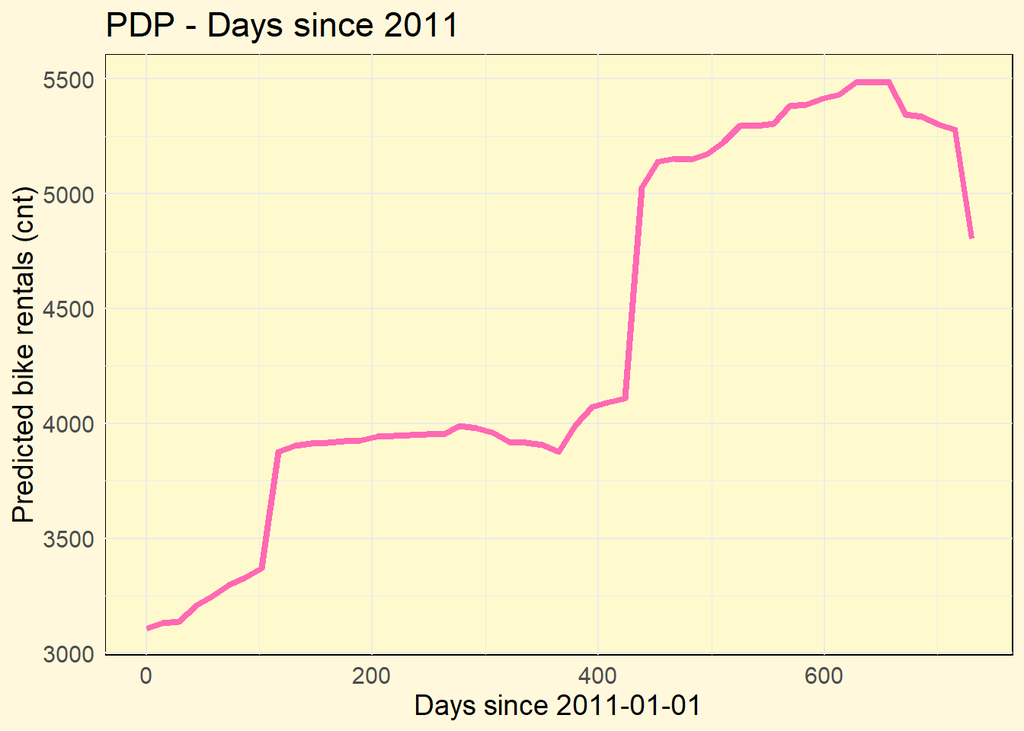

```r
p1 <- partial(bike_model, pred.var = "days_since_2011", train = bike)

autoplot(p1) +
  geom_line(color = "#ff69b4", linewidth = 1.5) +
  ggtitle("PDP - Days since 2011") +
  xlab("Days since 2011-01-01") +
  ylab("Predicted bike rentals (cnt)") +
  theme_minimal() +
  theme(
    plot.background  = element_rect(fill = "#fff8dc"),
    panel.background = element_rect(fill = "#fffacd"),
    text = element_text(size = 14)
  )
```

## PDP – Temperature

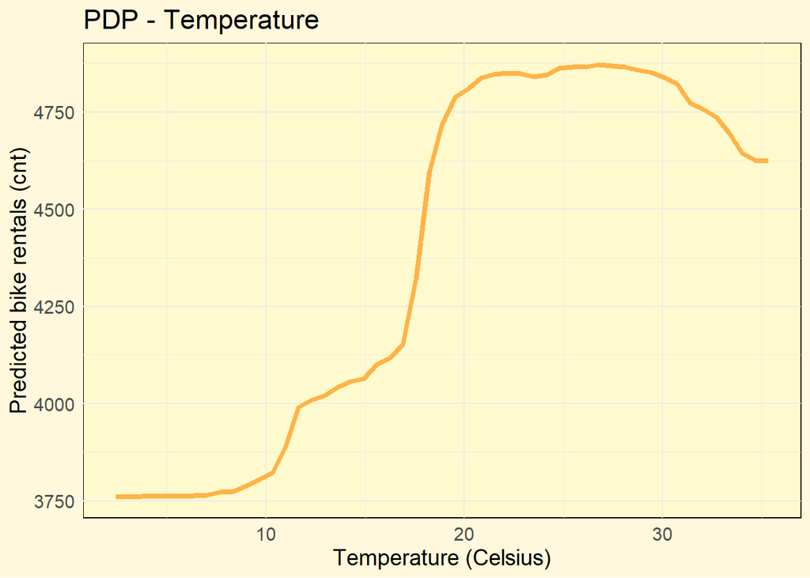

```r
p2 <- partial(bike_model, pred.var = "temp", train = bike)

autoplot(p2) +
  geom_line(color = "#ffb347", linewidth = 1.5) +
  ggtitle("PDP - Temperature") +
  xlab("Temperature (Celsius)") +
  ylab("Predicted bike rentals (cnt)") +
  theme_minimal() +
  theme(
    plot.background  = element_rect(fill = "#fff8dc"),
    panel.background = element_rect(fill = "#fffacd"),
    text = element_text(size = 14)
  )
```

## PDP – Humidity

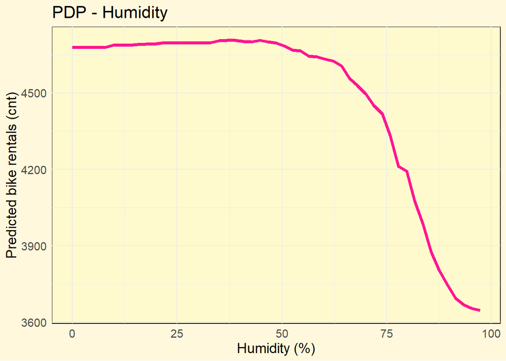

```r
p3 <- partial(bike_model, pred.var = "hum", train = bike)

autoplot(p3) +
  geom_line(color = "#ff1493", linewidth = 1.5) +
  ggtitle("PDP - Humidity") +
  xlab("Humidity (%)") +
  ylab("Predicted bike rentals (cnt)") +
  theme_minimal() +
  theme(
    plot.background  = element_rect(fill = "#fff8dc"),
    panel.background = element_rect(fill = "#fffacd"),
    text = element_text(size = 14)
  )
```

## PDP – Wind Speed

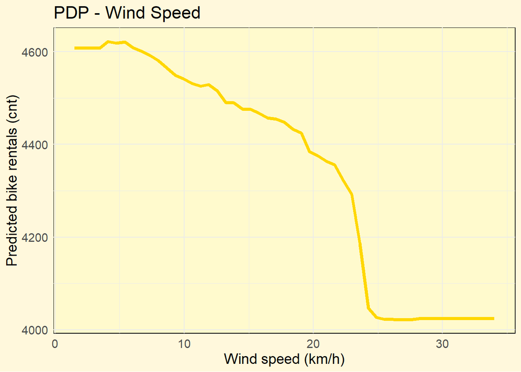

```r
p4 <- partial(bike_model, pred.var = "windspeed", train = bike)

autoplot(p4) +
  geom_line(color = "#ffd700", linewidth = 1.5) +
  ggtitle("PDP - Wind Speed") +
  xlab("Wind speed (km/h)") +
  ylab("Predicted bike rentals (cnt)") +
  theme_minimal() +
  theme(
    plot.background  = element_rect(fill = "#fff8dc"),
    panel.background = element_rect(fill = "#fffacd"),
    text = element_text(size = 14)
  )
```

## Interpretation

**Temperature (Celsius):** The relationship between temperature and predicted rentals follows a clear S-shaped curve. Predictions remain low and flat below 8°C (3750 rentals), then rise steeply between 10°C and 20°C, and stabilized between 20°C and 30°C at around 4850 rentals. Above 30°C, predictions noticeably decline to 4600, suggesting that extreme heat also discourages cycling. Temperature is one of the strongest predictors in the model, with an overall range of over 1000 predicted rentals across its values.

**Wind speed (km/h):** The PDP shows a gradual decrease in predicted rentals as wind speed increases from 0 to 20 km/h, followed by a very abrupt drop around 25 km/h (from 4350 to 4050). Above that point the curve flattens completely, indicating that the effect saturates at high wind speeds. This threshold around 25 km/h is the most notable feature of this PDP and suggests a critical comfort boundary for cyclists.

Temperature and days since 2011 are the strongest positive drivers of predicted bike rentals. Humidity and wind speed both act as negative moderators, but with distinct patterns: humidity has a threshold effect that only activates above 60–65%, while wind speed shows a sharp drop at around 25 km/h. Weather conditions explain short-term variation in demand, while the time trend captures the structural growth of the service across its two years of operation.

# Two-dimensional Partial Dependence Plot (Humidity & Temperature)

## Data Sampling

Due to the computational cost of generating a 2D PDP, a random subset of 300 rows was extracted from the preprocessed bike dataset.

```r
set.seed(123)
bike_sample <- bike[sample(nrow(bike), 300), ]
```

## 2D PDP – Temperature x Humidity

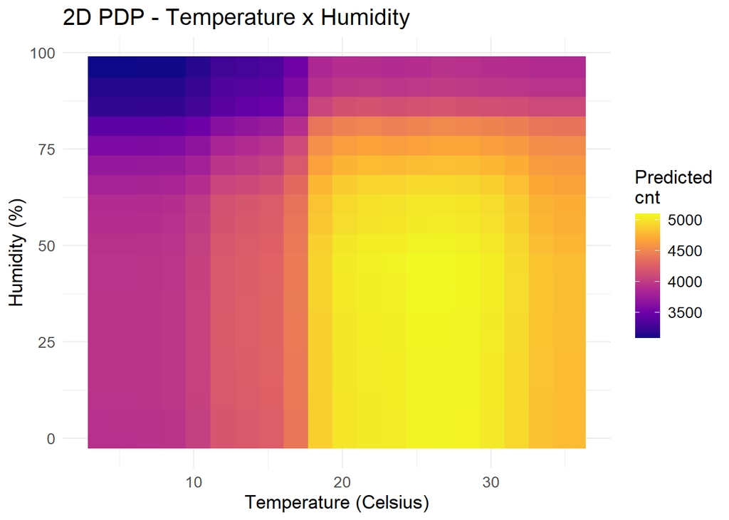

```r
pdp_2d <- partial(
  bike_model,
  pred.var        = c("temp", "hum"),
  train           = bike_sample,
  grid.resolution = 20
)

ggplot(pdp_2d, aes(x = temp, y = hum, fill = yhat)) +
  geom_tile(width = 2.2, height = 5.5) +
  scale_fill_viridis_c(option = "C", name = "Predicted\ncnt") +
  labs(
    title = "2D PDP - Temperature x Humidity",
    x     = "Temperature (Celsius)",
    y     = "Humidity (%)"
  ) +
  theme_minimal() +
  theme(text = element_text(size = 13))
```

## Density distribution of input features

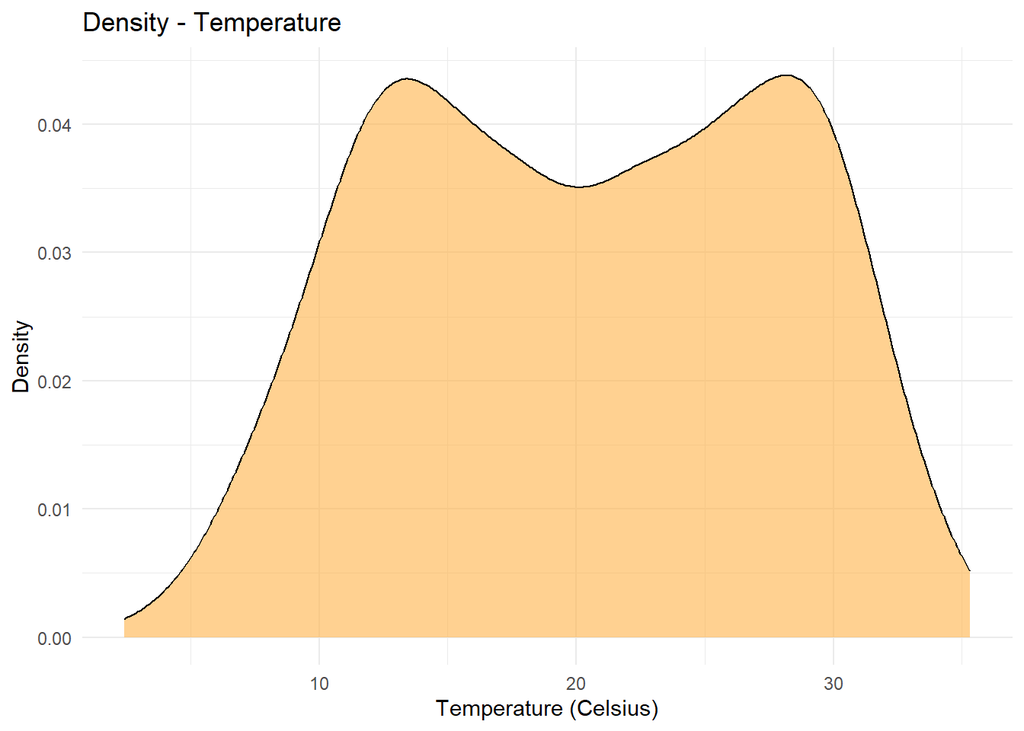

```r
ggplot(bike, aes(x = temp)) +
  geom_density(fill = "#ffb347", alpha = 0.6) +
  labs(title = "Density - Temperature", x = "Temperature (Celsius)", y = "Density") +
  theme_minimal()
```

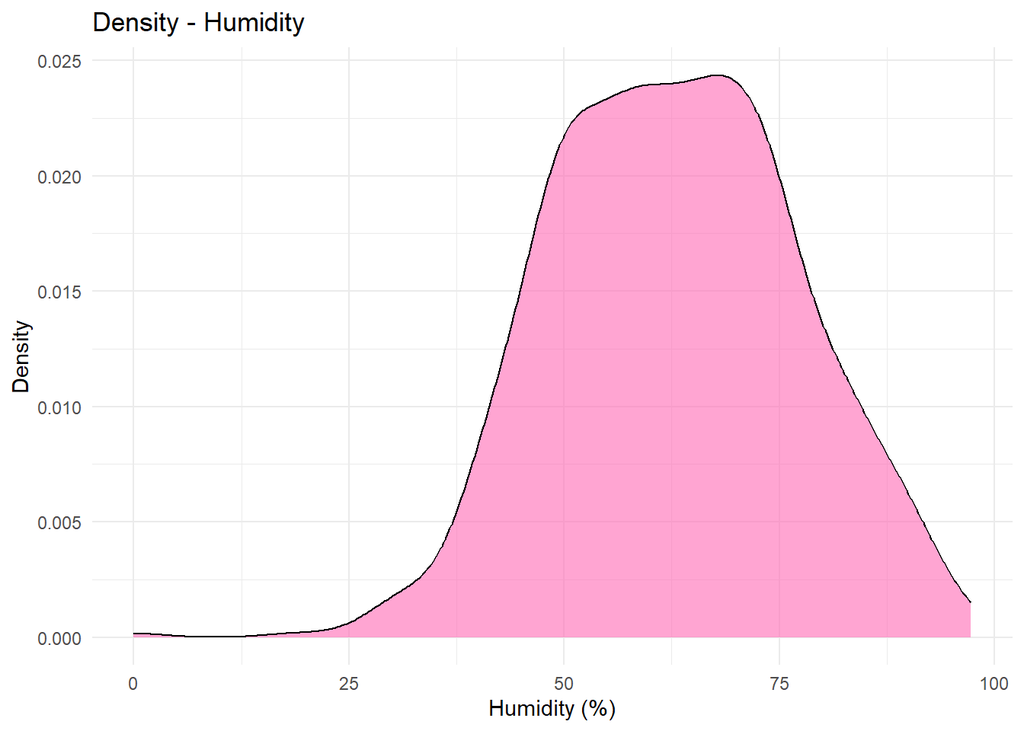

```r
ggplot(bike, aes(x = hum)) +
  geom_density(fill = "#ff69b4", alpha = 0.6) +
  labs(title = "Density - Humidity", x = "Humidity (%)", y = "Density") +
  theme_minimal()
```

## Interpretation

The **2D PDP** shows the joint marginal effect of temperature and humidity on predicted bike rentals. Warmer colors (yellow) indicate higher predicted counts, while cooler colors (purple/blue) indicate lower predictions.

The most striking feature of the plot is that the color pattern is predominantly vertical — within each temperature column, the color remains largely consistent across humidity levels. This indicates that temperature is the dominant driver of the joint prediction, with humidity playing a secondary role.

The **density plots** add important context. Temperature follows a bimodal distribution with peaks around 14°C and 28°C, reflecting the two seasonal cycles covered by the dataset. Humidity is concentrated between 50% and 80%, with very few observations below 25%. This means the bottom-left corner of the 2D plot — low humidity at any temperature — represents a sparse region of the training data, and predictions there should be interpreted with caution.

In summary, temperature dominates the joint prediction and humidity acts as a secondary moderator, only visibly dampening rentals above 80%. The most reliable predictions lie in the central zone of the plot (10–32°C, 45–80% humidity), which is where the bulk of the observed data falls.

# PDP for House Price Prediction

## Data Loading and Sampling

Due to the size of the dataset, a random subset of 3000 rows was extracted to reduce computational cost.

```r
house <- read.csv("C:/Users/Maria/Desktop/EDM/Task_XAI3/kc_house_data.csv")
set.seed(42)
house_sample <- house[sample(nrow(house), 3000), ]
```

## Model Training

A Random Forest regression model was trained to predict house prices using the features specified in the exercise: `bedrooms`, `bathrooms`, `sqft_living`, `sqft_lot`, `floors`, and `yr_built`.

```r
house_model <- randomForest(
  price ~ bedrooms + bathrooms + sqft_living + sqft_lot + floors + yr_built,
  data  = house_sample,
  ntree = 100
)
```

## PDP – Bedrooms

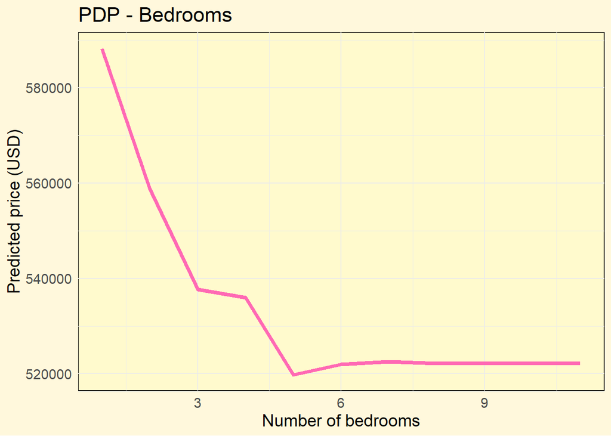

```r
h1 <- partial(house_model, pred.var = "bedrooms", train = house_sample)

autoplot(h1) +
  geom_line(color = "#ff69b4", linewidth = 1.5) +
  ggtitle("PDP - Bedrooms") +
  xlab("Number of bedrooms") +
  ylab("Predicted price (USD)") +
  theme_minimal() +
  theme(
    plot.background  = element_rect(fill = "#fff8dc"),
    panel.background = element_rect(fill = "#fffacd"),
    text = element_text(size = 14)
  )
```

## PDP – Bathrooms

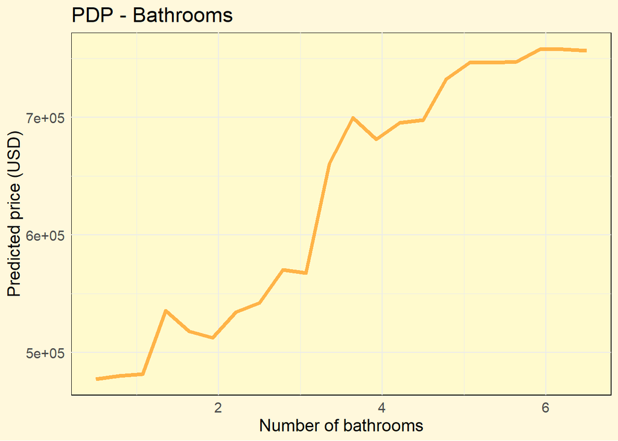

```r
h2 <- partial(house_model, pred.var = "bathrooms", train = house_sample)

autoplot(h2) +
  geom_line(color = "#ffb347", linewidth = 1.5) +
  ggtitle("PDP - Bathrooms") +
  xlab("Number of bathrooms") +
  ylab("Predicted price (USD)") +
  theme_minimal() +
  theme(
    plot.background  = element_rect(fill = "#fff8dc"),
    panel.background = element_rect(fill = "#fffacd"),
    text = element_text(size = 14)
  )
```

## PDP – Living Area (sqft_living)

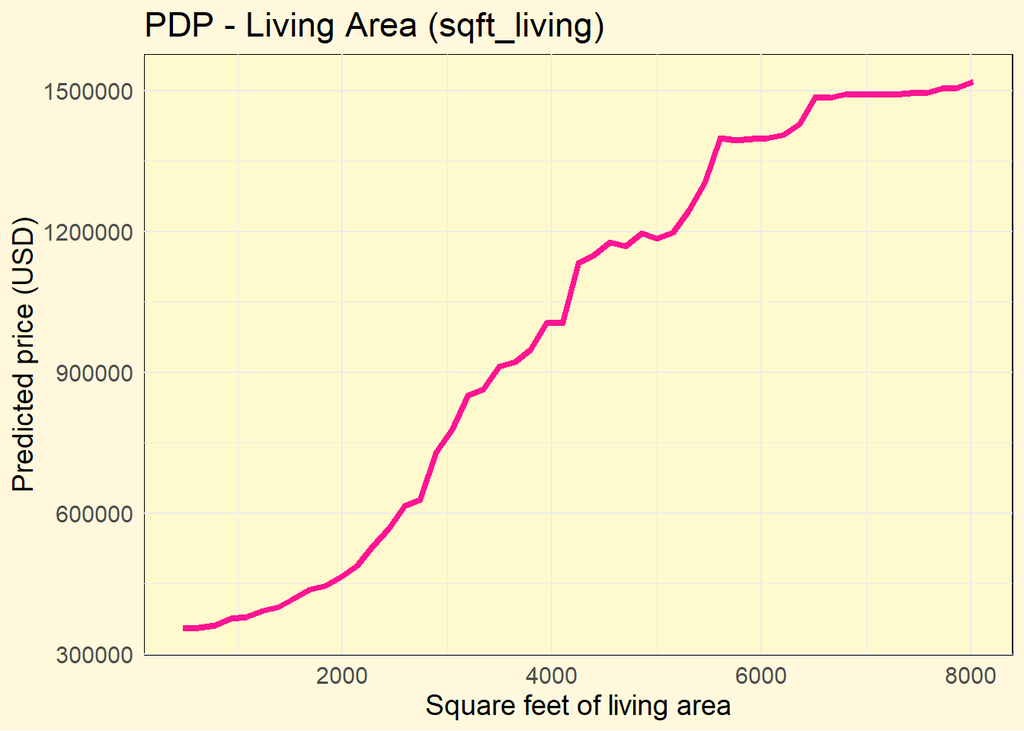

```r
h3 <- partial(house_model, pred.var = "sqft_living", train = house_sample)

autoplot(h3) +
  geom_line(color = "#ff1493", linewidth = 1.5) +
  ggtitle("PDP - Living Area (sqft_living)") +
  xlab("Square feet of living area") +
  ylab("Predicted price (USD)") +
  theme_minimal() +
  theme(
    plot.background  = element_rect(fill = "#fff8dc"),
    panel.background = element_rect(fill = "#fffacd"),
    text = element_text(size = 14)
  )
```

## PDP – Floors

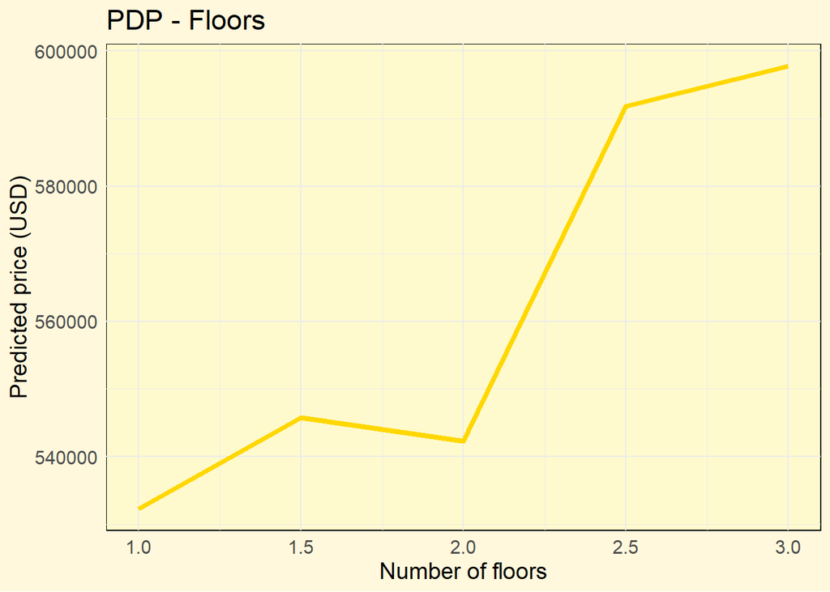

```r
h4 <- partial(house_model, pred.var = "floors", train = house_sample)

autoplot(h4) +
  geom_line(color = "#ffd700", linewidth = 1.5) +
  ggtitle("PDP - Floors") +
  xlab("Number of floors") +
  ylab("Predicted price (USD)") +
  theme_minimal() +
  theme(
    plot.background  = element_rect(fill = "#fff8dc"),
    panel.background = element_rect(fill = "#fffacd"),
    text = element_text(size = 14)
  )
```

## Influence of variables on the predicted price.

**Bedrooms:** The PDP reveals a surprising negative relationship between the number of bedrooms and predicted house price. Properties with 1–2 bedrooms are associated with the highest predicted prices ($600,000), which then drop sharply to around $538,000 at 3 bedrooms and continue declining to approximately $520,000 at 5–6 bedrooms, after which the curve flattens. This counterintuitive result likely reflects that, once living area and other features are held constant, more bedrooms imply smaller individual rooms, which buyers may perceive negatively. Bedrooms is therefore not a straightforward value driver in this model.

**Floors:** The effect of floors is modest but not uniform. Predicted prices increase slightly from 1 to 1.5 floors ($530,000 to $543,000) and remain nearly flat up to 2 floors ($541,000). The most notable jump occurs between 2 and 2.5 floors, where predictions rise sharply from $541,000 to ~$587,000. Above 2.5 floors the curve continues to rise slightly to $595,000 at 3 floors. The overall range is only about $65,000, making floors the weakest predictor among the four

# Conclusions

This practice demonstrated how Partial Dependence Plots can reveal the marginal effect of individual features on Random Forest predictions, going beyond simple importance scores by exposing the shape and direction of each relationship.

For bike rentals, temperature and time since 2011 are the strongest positive drivers, while humidity and wind speed reduce demand — but not uniformly. Both show threshold behaviour: humidity only penalises rentals sharply above 75–80%, and wind speed drops abruptly around 25 km/h. The 2D PDP confirmed that temperature dominates the joint prediction, with humidity acting as a secondary moderator only at its highest values.

For house prices, living area is the overwhelmingly dominant predictor, spanning a price range that dwarfs all other variables. Bathrooms contribute a strong positive effect, floors a modest one, and bedrooms — counterintuitively — show a negative marginal effect once living area is controlled for, suggesting that more bedrooms in a fixed-size house reduce rather than add value.

Overall, PDPs proved essential for uncovering non-linear and unexpected patterns that would remain hidden in standard model outputs, making them a valuable tool for interpretable machine learning.